# Risk Factor Analysis

## Outcome Variable

**Outcome Variable:** y_rate_lencm

## Predictor Variables

**Intervention Variable:** fage

**Adjustment Set:**

unadjusted

## Stratifying Variables

The analysis was stratified on these variable(s):

- diffcat
- studyid
- country

## Data Summary

| diffcat | studyid | country | fage | n_cell | n |
| --- | --- | --- | --- | --- | --- |
| 0-3 months | ki0047075b-MAL-ED | BANGLADESH | >=35 | 101 | 150 |
| 0-3 months | ki0047075b-MAL-ED | BANGLADESH | [25-30) | 14 | 150 |
| 0-3 months | ki0047075b-MAL-ED | BANGLADESH | [30-35) | 35 | 150 |
| 3-6 months | ki0047075b-MAL-ED | BANGLADESH | >=35 | 99 | 148 |
| 3-6 months | ki0047075b-MAL-ED | BANGLADESH | [25-30) | 14 | 148 |
| 3-6 months | ki0047075b-MAL-ED | BANGLADESH | [30-35) | 35 | 148 |
| 6-12 months | ki0047075b-MAL-ED | BANGLADESH | >=35 | 98 | 145 |
| 6-12 months | ki0047075b-MAL-ED | BANGLADESH | [25-30) | 14 | 145 |
| 6-12 months | ki0047075b-MAL-ED | BANGLADESH | [30-35) | 33 | 145 |
| 12-24 months | ki0047075b-MAL-ED | BANGLADESH | >=35 | 99 | 146 |
| 12-24 months | ki0047075b-MAL-ED | BANGLADESH | [25-30) | 14 | 146 |
| 12-24 months | ki0047075b-MAL-ED | BANGLADESH | [30-35) | 33 | 146 |
| 0-3 months | ki1119695-PROBIT | BELARUS | >=35 | 1242 | 12294 |
| 0-3 months | ki1119695-PROBIT | BELARUS | <25 | 4068 | 12294 |
| 0-3 months | ki1119695-PROBIT | BELARUS | [25-30) | 4633 | 12294 |
| 0-3 months | ki1119695-PROBIT | BELARUS | [30-35) | 2351 | 12294 |
| 3-6 months | ki1119695-PROBIT | BELARUS | >=35 | 1293 | 12816 |
| 3-6 months | ki1119695-PROBIT | BELARUS | <25 | 4314 | 12816 |
| 3-6 months | ki1119695-PROBIT | BELARUS | [25-30) | 4809 | 12816 |
| 3-6 months | ki1119695-PROBIT | BELARUS | [30-35) | 2400 | 12816 |
| 6-12 months | ki1119695-PROBIT | BELARUS | >=35 | 1275 | 12439 |
| 6-12 months | ki1119695-PROBIT | BELARUS | <25 | 4168 | 12439 |
| 6-12 months | ki1119695-PROBIT | BELARUS | [25-30) | 4659 | 12439 |
| 6-12 months | ki1119695-PROBIT | BELARUS | [30-35) | 2337 | 12439 |
| 12-24 months | ki1119695-PROBIT | BELARUS | >=35 | 268 | 2462 |
| 12-24 months | ki1119695-PROBIT | BELARUS | <25 | 764 | 2462 |
| 12-24 months | ki1119695-PROBIT | BELARUS | [25-30) | 959 | 2462 |
| 12-24 months | ki1119695-PROBIT | BELARUS | [30-35) | 471 | 2462 |
| 0-3 months | ki0047075b-MAL-ED | BRAZIL | >=35 | 35 | 68 |
| 0-3 months | ki0047075b-MAL-ED | BRAZIL | <25 | 3 | 68 |

[output cut: 158 more lines]

The following strata were considered:

- diffcat: 0-3 months, studyid: ki0047075b-MAL-ED, country: BANGLADESH
- diffcat: 0-3 months, studyid: ki0047075b-MAL-ED, country: BRAZIL
- diffcat: 0-3 months, studyid: ki0047075b-MAL-ED, country: INDIA
- diffcat: 0-3 months, studyid: ki0047075b-MAL-ED, country: NEPAL
- diffcat: 0-3 months, studyid: ki0047075b-MAL-ED, country: PERU
- diffcat: 0-3 months, studyid: ki0047075b-MAL-ED, country: SOUTH AFRICA
- diffcat: 0-3 months, studyid: ki0047075b-MAL-ED, country: TANZANIA, UNITED REPUBLIC OF
- diffcat: 0-3 months, studyid: ki1000304b-SAS-CompFeed, country: INDIA
- diffcat: 0-3 months, studyid: ki1119695-PROBIT, country: BELARUS
- diffcat: 0-3 months, studyid: ki1135781-COHORTS, country: GUATEMALA
- diffcat: 12-24 months, studyid: ki0047075b-MAL-ED, country: BANGLADESH
- diffcat: 12-24 months, studyid: ki0047075b-MAL-ED, country: BRAZIL
- diffcat: 12-24 months, studyid: ki0047075b-MAL-ED, country: INDIA
- diffcat: 12-24 months, studyid: ki0047075b-MAL-ED, country: NEPAL
- diffcat: 12-24 months, studyid: ki0047075b-MAL-ED, country: PERU
- diffcat: 12-24 months, studyid: ki0047075b-MAL-ED, country: SOUTH AFRICA
- diffcat: 12-24 months, studyid: ki0047075b-MAL-ED, country: TANZANIA, UNITED REPUBLIC OF
- diffcat: 12-24 months, studyid: ki1119695-PROBIT, country: BELARUS
- diffcat: 12-24 months, studyid: ki1135781-COHORTS, country: GUATEMALA
- diffcat: 12-24 months, studyid: ki1135781-COHORTS, country: PHILIPPINES
- diffcat: 12-24 months, studyid: ki1148112-iLiNS-DOSE, country: MALAWI
- diffcat: 12-24 months, studyid: ki1148112-iLiNS-DYAD-M, country: MALAWI
- diffcat: 12-24 months, studyid: ki1148112-LCNI-5, country: MALAWI
- diffcat: 3-6 months, studyid: ki0047075b-MAL-ED, country: BANGLADESH
- diffcat: 3-6 months, studyid: ki0047075b-MAL-ED, country: BRAZIL
- diffcat: 3-6 months, studyid: ki0047075b-MAL-ED, country: INDIA
- diffcat: 3-6 months, studyid: ki0047075b-MAL-ED, country: NEPAL
- diffcat: 3-6 months, studyid: ki0047075b-MAL-ED, country: PERU
- diffcat: 3-6 months, studyid: ki0047075b-MAL-ED, country: SOUTH AFRICA
- diffcat: 3-6 months, studyid: ki0047075b-MAL-ED, country: TANZANIA, UNITED REPUBLIC OF
- diffcat: 3-6 months, studyid: ki1000304b-SAS-CompFeed, country: INDIA
- diffcat: 3-6 months, studyid: ki1119695-PROBIT, country: BELARUS
- diffcat: 3-6 months, studyid: ki1135781-COHORTS, country: GUATEMALA
- diffcat: 3-6 months, studyid: ki1148112-iLiNS-DYAD-M, country: MALAWI
- diffcat: 6-12 months, studyid: ki0047075b-MAL-ED, country: BANGLADESH
- diffcat: 6-12 months, studyid: ki0047075b-MAL-ED, country: BRAZIL
- diffcat: 6-12 months, studyid: ki0047075b-MAL-ED, country: INDIA
- diffcat: 6-12 months, studyid: ki0047075b-MAL-ED, country: NEPAL
- diffcat: 6-12 months, studyid: ki0047075b-MAL-ED, country: PERU
- diffcat: 6-12 months, studyid: ki0047075b-MAL-ED, country: SOUTH AFRICA
- diffcat: 6-12 months, studyid: ki0047075b-MAL-ED, country: TANZANIA, UNITED REPUBLIC OF
- diffcat: 6-12 months, studyid: ki1000304b-SAS-CompFeed, country: INDIA
- diffcat: 6-12 months, studyid: ki1000304b-SAS-FoodSuppl, country: INDIA
- diffcat: 6-12 months, studyid: ki1119695-PROBIT, country: BELARUS
- diffcat: 6-12 months, studyid: ki1135781-COHORTS, country: GUATEMALA
- diffcat: 6-12 months, studyid: ki1135781-COHORTS, country: PHILIPPINES
- diffcat: 6-12 months, studyid: ki1148112-iLiNS-DOSE, country: MALAWI
- diffcat: 6-12 months, studyid: ki1148112-iLiNS-DYAD-M, country: MALAWI
- diffcat: 6-12 months, studyid: ki1148112-LCNI-5, country: MALAWI

### Dropped Strata

Some strata were dropped due to rare outcomes:

- diffcat: 0-3 months, studyid: ki0047075b-MAL-ED, country: BRAZIL
- diffcat: 3-6 months, studyid: ki0047075b-MAL-ED, country: BRAZIL
- diffcat: 6-12 months, studyid: ki0047075b-MAL-ED, country: BRAZIL
- diffcat: 12-24 months, studyid: ki0047075b-MAL-ED, country: BRAZIL
- diffcat: 0-3 months, studyid: ki0047075b-MAL-ED, country: INDIA
- diffcat: 3-6 months, studyid: ki0047075b-MAL-ED, country: INDIA
- diffcat: 6-12 months, studyid: ki0047075b-MAL-ED, country: INDIA
- diffcat: 12-24 months, studyid: ki0047075b-MAL-ED, country: INDIA
- diffcat: 3-6 months, studyid: ki1148112-iLiNS-DYAD-M, country: MALAWI
- diffcat: 0-3 months, studyid: ki0047075b-MAL-ED, country: PERU
- diffcat: 6-12 months, studyid: ki0047075b-MAL-ED, country: PERU
- diffcat: 12-24 months, studyid: ki0047075b-MAL-ED, country: PERU
- diffcat: 0-3 months, studyid: ki0047075b-MAL-ED, country: SOUTH AFRICA
- diffcat: 3-6 months, studyid: ki0047075b-MAL-ED, country: SOUTH AFRICA
- diffcat: 6-12 months, studyid: ki0047075b-MAL-ED, country: SOUTH AFRICA
- diffcat: 12-24 months, studyid: ki0047075b-MAL-ED, country: SOUTH AFRICA
- diffcat: 0-3 months, studyid: ki0047075b-MAL-ED, country: TANZANIA, UNITED REPUBLIC OF
- diffcat: 3-6 months, studyid: ki0047075b-MAL-ED, country: TANZANIA, UNITED REPUBLIC OF
- diffcat: 6-12 months, studyid: ki0047075b-MAL-ED, country: TANZANIA, UNITED REPUBLIC OF
- diffcat: 12-24 months, studyid: ki0047075b-MAL-ED, country: TANZANIA, UNITED REPUBLIC OF

## Methods Detail

We’re interested in the causal parameters $E[Y_a]$ for all values of $a \in \mathcal{A}$. These parameters represent the mean outcome if, possibly contrary to fact, we intervened to set all units to have $A=a$. Under the randomization and positivity assumptions, these are identified by the statistical parameters $\psi_a=E_W[E_{Y|A,W}(Y|A=a,W)]$. In addition, we’re interested in the mean of $Y$, $E[Y]$ under no intervention (the observed mean). We will estimate these parameters by using SuperLearner to fit the relevant likelihood factors – $E_{Y|A,W}(Y|A=a,W)$ and $p(A=a|W)$, and then updating our likelihood fit using a joint TMLE.

For unadjusted analyses ($W=\{\}$), initial likelihoods were estimated using Lrnr_glm to estimate the simple $E(Y|A)$ and Lrnr_mean to estimate $p(A)$. For adjusted analyses, a small library containing Lrnr_glmnet, Lrnr_xgboost, and Lrnr_mean was used.

Having estimated these parameters, we will then use the delta method to estimate relative risks and attributable risks relative to a prespecified baseline level of $A$.

# Results Detail

## Results Plots

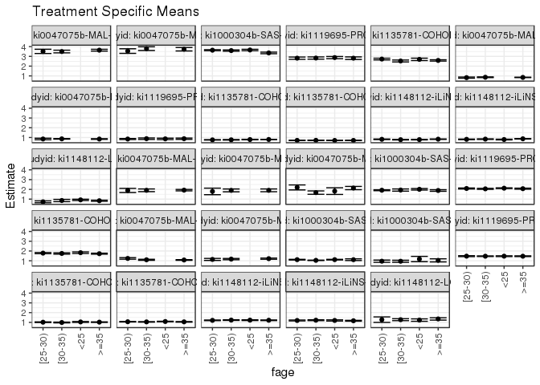

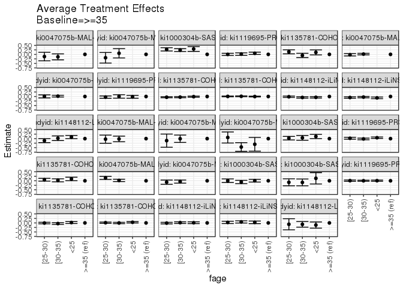

## Results Table

### Parameter: TSM

| diffcat | studyid | country | intervention_level | baseline_level | estimate | ci_lower | ci_upper |
| --- | --- | --- | --- | --- | --- | --- | --- |
| 0-3 months | ki0047075b-MAL-ED | BANGLADESH | >=35 | NA | 3.6323800 | 3.5384951 | 3.7262649 |
| 0-3 months | ki0047075b-MAL-ED | BANGLADESH | [25-30) | NA | 3.5108652 | 3.2939552 | 3.7277751 |
| 0-3 months | ki0047075b-MAL-ED | BANGLADESH | [30-35) | NA | 3.4945473 | 3.3578616 | 3.6312331 |
| 0-3 months | ki0047075b-MAL-ED | NEPAL | >=35 | NA | 3.7306968 | 3.5542923 | 3.9071013 |
| 0-3 months | ki0047075b-MAL-ED | NEPAL | [25-30) | NA | 3.5424058 | 3.3069894 | 3.7778222 |
| 0-3 months | ki0047075b-MAL-ED | NEPAL | [30-35) | NA | 3.7913607 | 3.6025850 | 3.9801363 |
| 0-3 months | ki1000304b-SAS-CompFeed | INDIA | >=35 | NA | 3.3534672 | 3.2718305 | 3.4351038 |
| 0-3 months | ki1000304b-SAS-CompFeed | INDIA | <25 | NA | 3.6521293 | 3.5770358 | 3.7272228 |
| 0-3 months | ki1000304b-SAS-CompFeed | INDIA | [25-30) | NA | 3.6310867 | 3.5769726 | 3.6852008 |
| 0-3 months | ki1000304b-SAS-CompFeed | INDIA | [30-35) | NA | 3.5915526 | 3.5251351 | 3.6579701 |
| 0-3 months | ki1119695-PROBIT | BELARUS | >=35 | NA | 2.8132559 | 2.6818884 | 2.9446234 |
| 0-3 months | ki1119695-PROBIT | BELARUS | <25 | NA | 2.8739677 | 2.7630404 | 2.9848949 |
| 0-3 months | ki1119695-PROBIT | BELARUS | [25-30) | NA | 2.8142168 | 2.6961914 | 2.9322421 |
| 0-3 months | ki1119695-PROBIT | BELARUS | [30-35) | NA | 2.8271888 | 2.7123779 | 2.9419996 |
| 0-3 months | ki1135781-COHORTS | GUATEMALA | >=35 | NA | 2.5830843 | 2.5153724 | 2.6507962 |
| 0-3 months | ki1135781-COHORTS | GUATEMALA | <25 | NA | 2.6926907 | 2.5718447 | 2.8135368 |
| 0-3 months | ki1135781-COHORTS | GUATEMALA | [25-30) | NA | 2.7245124 | 2.6360661 | 2.8129587 |
| 0-3 months | ki1135781-COHORTS | GUATEMALA | [30-35) | NA | 2.5253565 | 2.4269850 | 2.6237281 |
| 3-6 months | ki0047075b-MAL-ED | BANGLADESH | >=35 | NA | 1.9217371 | 1.8477505 | 1.9957236 |
| 3-6 months | ki0047075b-MAL-ED | BANGLADESH | [25-30) | NA | 1.8926273 | 1.6795496 | 2.1057050 |
| 3-6 months | ki0047075b-MAL-ED | BANGLADESH | [30-35) | NA | 1.9056882 | 1.7682563 | 2.0431201 |
| 3-6 months | ki0047075b-MAL-ED | NEPAL | >=35 | NA | 1.9023503 | 1.7589779 | 2.0457226 |
| 3-6 months | ki0047075b-MAL-ED | NEPAL | [25-30) | NA | 1.7917742 | 1.4557970 | 2.1277514 |
| 3-6 months | ki0047075b-MAL-ED | NEPAL | [30-35) | NA | 1.8964764 | 1.7512588 | 2.0416941 |
| 3-6 months | ki0047075b-MAL-ED | PERU | >=35 | NA | 2.1344972 | 1.9664696 | 2.3025249 |
| 3-6 months | ki0047075b-MAL-ED | PERU | <25 | NA | 1.8217963 | 1.4800023 | 2.1635904 |
| 3-6 months | ki0047075b-MAL-ED | PERU | [25-30) | NA | 2.1985747 | 1.9422203 | 2.4549290 |
| 3-6 months | ki0047075b-MAL-ED | PERU | [30-35) | NA | 1.6696880 | 1.4973765 | 1.8419995 |
| 3-6 months | ki1000304b-SAS-CompFeed | INDIA | >=35 | NA | 1.8868467 | 1.8066756 | 1.9670177 |
| 3-6 months | ki1000304b-SAS-CompFeed | INDIA | <25 | NA | 2.0070724 | 1.9288053 | 2.0853395 |

[output cut: 78 more lines]

### Parameter: E(Y)

| diffcat | studyid | country | intervention_level | baseline_level | estimate | ci_lower | ci_upper |
| --- | --- | --- | --- | --- | --- | --- | --- |
| 0-3 months | ki0047075b-MAL-ED | BANGLADESH | NA | NA | 3.5888777 | 3.5145520 | 3.6632034 |
| 0-3 months | ki0047075b-MAL-ED | NEPAL | NA | NA | 3.7328856 | 3.6136585 | 3.8521128 |
| 0-3 months | ki1000304b-SAS-CompFeed | INDIA | NA | NA | 3.6022342 | 3.5739584 | 3.6305100 |
| 0-3 months | ki1119695-PROBIT | BELARUS | NA | NA | 2.8363715 | 2.7230464 | 2.9496966 |
| 0-3 months | ki1135781-COHORTS | GUATEMALA | NA | NA | 2.6164613 | 2.5719057 | 2.6610169 |
| 3-6 months | ki0047075b-MAL-ED | BANGLADESH | NA | NA | 1.9151881 | 1.8526222 | 1.9777540 |
| 3-6 months | ki0047075b-MAL-ED | NEPAL | NA | NA | 1.8860484 | 1.7866718 | 1.9854250 |
| 3-6 months | ki0047075b-MAL-ED | PERU | NA | NA | 2.0391824 | 1.9190819 | 2.1592828 |
| 3-6 months | ki1000304b-SAS-CompFeed | INDIA | NA | NA | 1.9401040 | 1.8974682 | 1.9827398 |
| 3-6 months | ki1119695-PROBIT | BELARUS | NA | NA | 2.0923463 | 2.0510631 | 2.1336294 |
| 3-6 months | ki1135781-COHORTS | GUATEMALA | NA | NA | 1.7566595 | 1.7253717 | 1.7879472 |
| 6-12 months | ki0047075b-MAL-ED | BANGLADESH | NA | NA | 1.1000336 | 1.0701340 | 1.1299332 |
| 6-12 months | ki0047075b-MAL-ED | NEPAL | NA | NA | 1.1874519 | 1.1469747 | 1.2279292 |
| 6-12 months | ki1000304b-SAS-CompFeed | INDIA | NA | NA | 1.0994077 | 1.0886490 | 1.1101664 |
| 6-12 months | ki1000304b-SAS-FoodSuppl | INDIA | NA | NA | 1.0131058 | 0.9370457 | 1.0891660 |
| 6-12 months | ki1119695-PROBIT | BELARUS | NA | NA | 1.4697464 | 1.4316817 | 1.5078110 |
| 6-12 months | ki1135781-COHORTS | GUATEMALA | NA | NA | 1.0185687 | 1.0012009 | 1.0359366 |
| 6-12 months | ki1135781-COHORTS | PHILIPPINES | NA | NA | 1.0672226 | 1.0548911 | 1.0795541 |
| 6-12 months | ki1148112-iLiNS-DOSE | MALAWI | NA | NA | 1.2216707 | 1.2046358 | 1.2387056 |
| 6-12 months | ki1148112-iLiNS-DYAD-M | MALAWI | NA | NA | 1.1961675 | 1.1725424 | 1.2197926 |
| 6-12 months | ki1148112-LCNI-5 | MALAWI | NA | NA | 1.2956565 | 1.2080181 | 1.3832950 |
| 12-24 months | ki0047075b-MAL-ED | BANGLADESH | NA | NA | 0.8462936 | 0.8276071 | 0.8649800 |
| 12-24 months | ki0047075b-MAL-ED | NEPAL | NA | NA | 0.8519576 | 0.8288134 | 0.8751019 |
| 12-24 months | ki1119695-PROBIT | BELARUS | NA | NA | 0.8606477 | 0.8070689 | 0.9142264 |
| 12-24 months | ki1135781-COHORTS | GUATEMALA | NA | NA | 0.7806173 | 0.7696290 | 0.7916055 |
| 12-24 months | ki1135781-COHORTS | PHILIPPINES | NA | NA | 0.7056723 | 0.6982628 | 0.7130818 |
| 12-24 months | ki1148112-iLiNS-DOSE | MALAWI | NA | NA | 0.8069797 | 0.7928804 | 0.8210791 |
| 12-24 months | ki1148112-iLiNS-DYAD-M | MALAWI | NA | NA | 0.8317594 | 0.8167916 | 0.8467271 |
| 12-24 months | ki1148112-LCNI-5 | MALAWI | NA | NA | 0.8389480 | 0.7933802 | 0.8845158 |

### Parameter: ATE

| diffcat | studyid | country | intervention_level | baseline_level | estimate | ci_lower | ci_upper |
| --- | --- | --- | --- | --- | --- | --- | --- |
| 0-3 months | ki0047075b-MAL-ED | BANGLADESH | >=35 | >=35 | 0.0000000 | 0.0000000 | 0.0000000 |
| 0-3 months | ki0047075b-MAL-ED | BANGLADESH | [25-30) | >=35 | -0.1215148 | -0.3578711 | 0.1148415 |
| 0-3 months | ki0047075b-MAL-ED | BANGLADESH | [30-35) | >=35 | -0.1378327 | -0.3036560 | 0.0279907 |
| 0-3 months | ki0047075b-MAL-ED | NEPAL | >=35 | >=35 | 0.0000000 | 0.0000000 | 0.0000000 |
| 0-3 months | ki0047075b-MAL-ED | NEPAL | [25-30) | >=35 | -0.1882910 | -0.4824668 | 0.1058849 |
| 0-3 months | ki0047075b-MAL-ED | NEPAL | [30-35) | >=35 | 0.0606639 | -0.1977056 | 0.3190334 |
| 0-3 months | ki1000304b-SAS-CompFeed | INDIA | >=35 | >=35 | 0.0000000 | 0.0000000 | 0.0000000 |
| 0-3 months | ki1000304b-SAS-CompFeed | INDIA | <25 | >=35 | 0.2986621 | 0.1642393 | 0.4330850 |
| 0-3 months | ki1000304b-SAS-CompFeed | INDIA | [25-30) | >=35 | 0.2776196 | 0.1874649 | 0.3677742 |
| 0-3 months | ki1000304b-SAS-CompFeed | INDIA | [30-35) | >=35 | 0.2380854 | 0.1586000 | 0.3175708 |
| 0-3 months | ki1119695-PROBIT | BELARUS | >=35 | >=35 | 0.0000000 | 0.0000000 | 0.0000000 |
| 0-3 months | ki1119695-PROBIT | BELARUS | <25 | >=35 | 0.0607118 | -0.0010067 | 0.1224302 |
| 0-3 months | ki1119695-PROBIT | BELARUS | [25-30) | >=35 | 0.0009609 | -0.0600647 | 0.0619864 |
| 0-3 months | ki1119695-PROBIT | BELARUS | [30-35) | >=35 | 0.0139329 | -0.0556822 | 0.0835479 |
| 0-3 months | ki1135781-COHORTS | GUATEMALA | >=35 | >=35 | 0.0000000 | 0.0000000 | 0.0000000 |
| 0-3 months | ki1135781-COHORTS | GUATEMALA | <25 | >=35 | 0.1096064 | -0.0289167 | 0.2481296 |
| 0-3 months | ki1135781-COHORTS | GUATEMALA | [25-30) | >=35 | 0.1414281 | 0.0300384 | 0.2528177 |
| 0-3 months | ki1135781-COHORTS | GUATEMALA | [30-35) | >=35 | -0.0577278 | -0.1771508 | 0.0616953 |
| 3-6 months | ki0047075b-MAL-ED | BANGLADESH | >=35 | >=35 | 0.0000000 | 0.0000000 | 0.0000000 |
| 3-6 months | ki0047075b-MAL-ED | BANGLADESH | [25-30) | >=35 | -0.0291098 | -0.2546671 | 0.1964476 |
| 3-6 months | ki0047075b-MAL-ED | BANGLADESH | [30-35) | >=35 | -0.0160489 | -0.1721307 | 0.1400330 |
| 3-6 months | ki0047075b-MAL-ED | NEPAL | >=35 | >=35 | 0.0000000 | 0.0000000 | 0.0000000 |
| 3-6 months | ki0047075b-MAL-ED | NEPAL | [25-30) | >=35 | -0.1105761 | -0.4758654 | 0.2547133 |
| 3-6 months | ki0047075b-MAL-ED | NEPAL | [30-35) | >=35 | -0.0058739 | -0.2099420 | 0.1981943 |
| 3-6 months | ki0047075b-MAL-ED | PERU | >=35 | >=35 | 0.0000000 | 0.0000000 | 0.0000000 |
| 3-6 months | ki0047075b-MAL-ED | PERU | <25 | >=35 | -0.3127009 | -0.6935637 | 0.0681619 |
| 3-6 months | ki0047075b-MAL-ED | PERU | [25-30) | >=35 | 0.0640775 | -0.2424366 | 0.3705915 |
| 3-6 months | ki0047075b-MAL-ED | PERU | [30-35) | >=35 | -0.4648092 | -0.7054844 | -0.2241340 |
| 3-6 months | ki1000304b-SAS-CompFeed | INDIA | >=35 | >=35 | 0.0000000 | 0.0000000 | 0.0000000 |
| 3-6 months | ki1000304b-SAS-CompFeed | INDIA | <25 | >=35 | 0.1202258 | 0.0017627 | 0.2386888 |

[output cut: 78 more lines]